# feather river redd data exploration

2024-06-28

Goal of this document is to revisit Feather River redd data and understand the following:

- what data are collected?
- what is the quality of the data?
- what are the data limitations?

# Relevant Science Plan hypotheses

1. Spawning habitat acreage

From Science Plan: “The metric for this hypothesis will be the acreage of spawning habitat with suitable water depths and velocities, and sizes of spawning gravel. Spawning habitat criteria, including depth, velocity, and target spawning substrate size will be defined in the specific VA action science and monitoring plan and associated design documents. The suitable gravel size for spawning habitat will be a range and distribution of spawning substrate sizes specific to the spawning population and hydrogeomorphic conditions in each tributary.”

This hypothesis was set up to use depth and velocity criteria to map spawning habitat acreage and compare to existing habitat. We could map spawning habitat based on redd locations over time. We would need latitude and longitude of all redds observed.

2. Salmon redd density (this is the most relevant hypothesis)

From Science Plan: “The metric for this hypothesis will be the number of Chinook salmon redds per unit area in habitat enhancement project areas, while also accounting for the potential for redd superimposition. The baseline for this hypothesis will be the redd density and superimposition rate at habitat enhancement locations compared to adjacent areas within the same reach, measured concurrently along with water quality criteria. In systems where redd mapping has been conducted consistently at both project locations and adjacent, non-enhanced locations, historical data can also be leveraged to examine trends and changes in redd density after the enhancement action.”

This is the number of redds per unit area. We would need a count of redds and some sort of delineation of the area where redds are occurring (this could be latitude/longitude of redd or river mile/reach surveyed, assuming whole area is surveyed)

3. Natural origin adult Chinook salmon population estimates by tributary, and trend in abundance (harvest plus escapement)

From Science Plan: “The metric for this hypothesis will be annual natural-origin adult Chinook salmon cohort replacement rates and trends over multiple years (e.g., > 3 years) over the period of VA implementation. The baseline for this hypothesis will be the annual natural-origin adult Chinook salmon cohort replacement rate trends during the period associated with the Anadromous Fish Restoration Program Doubling Goal (years 1967-1991). A secondary baseline, to reflect recent conditions and population numbers, will be annual adult Chinook salmon cohort replacement rates and trends for natural-origin fall run Chinook salmon since 2010.”

# What data are collected

*Contact*

These data were originally acquired from Chris Cook

*Timeframe*

```r
feather_redd_raw |> glimpse()
```

```
## Rows: 28,296
## Columns: 17
## $ date                     <date> 2009-09-29, 2009-09-29, 2009-09-29, 2009-09-…
## $ location                 <chr> "Table Mountain", "Table Mountain", "Table Mo…
## $ type                     <chr> "Area", "Point", "Area", "Area", "Area", "Are…
## $ redd_count               <dbl> 1, 1, 1, 1, 1, 1, 1, 3, 1, 1, 1, 1, 1, 1, 1, …
## $ salmon_count             <dbl> 0, 0, 0, 0, 0, 0, 0, 0, 0, 0, 0, 0, 0, 0, 0, …
## $ depth_m                  <dbl> 0.78, 0.56, 0.64, 0.50, 0.40, 0.52, 0.58, 0.3…
## $ pot_depth_m              <dbl> 0.00, 0.00, 0.00, 0.00, 0.00, 0.00, 0.00, 0.0…
## $ velocity                 <dbl> 0.000000, 0.000000, 0.000000, 0.000000, 0.000…
## $ percent_fine_substrate   <dbl> 10, 5, 15, 30, 25, 5, 5, 20, NA, NA, NA, NA, …
## $ percent_small_substrate  <dbl> 20, 20, 30, 50, 15, 15, 20, 20, NA, NA, NA, N…
## $ percent_medium_substrate <dbl> 40, 30, 20, 20, 60, 30, 20, 60, NA, NA, NA, N…
## $ percent_large_substrate  <dbl> 30, 40, 30, 0, 0, 50, 45, 0, NA, NA, NA, NA, …
## $ percent_boulder          <dbl> 0, 5, 5, 0, 0, 0, 0, 0, NA, NA, NA, NA, NA, N…
## $ redd_width_m             <dbl> NA, 0.91, 0.91, 0.91, 1.22, 0.91, 0.91, 3.66,…
## $ redd_length_m            <dbl> NA, 1.22, 1.52, 1.22, 1.83, 0.91, 0.91, 1.22,…
## $ latitude                 <dbl> NA, NA, NA, NA, NA, NA, NA, NA, NA, NA, NA, N…
## $ longitude                <dbl> NA, NA, NA, NA, NA, NA, NA, NA, NA, NA, NA, N…
```

## Questions

- Need to better understand `type` field. Do “area” measurements have a shapefile associated with them? Is “point” meant to communicate that a specific point measurement was taken for a redd?
- Why is the `redd_count` not always 1? If greater than 1 does that mean that redd specific measurements like depth are not collected?
- Does salmon count mean that salmon were observed on redd? No species or run differentiation?
- Where are depth measurements taken (just depth, not pot depth)?
- Does `pot_depth` refer to the depth of the pit?
- How are velocity measurements taken? Collected right above redd?
- Where is width measured?
- Latitude/Longitude unit system is inconsistent. Up until 2013, coordinate system is UTM, years following are shown as “latitude mn / longitude me” (probably zone 10). [This is some information we have found about that coordinate system](https://gis.stackexchange.com/questions/111847/what-kind-of-coordinate-system-has-values-like-48569-800me-706602-032mn). Why were the coordinate systems different, and how can we convert from mn/me to UTM?
- “area” `type` does not appear after year 2015. Did any methodology change, is there a reason why it was only “point”?
- are each of the location sampled multiple times a year, or does locations changed overtime?

# Data quality

- The data consistently collected include: date, location, survey_type, redd_count, salmon_count.
- All other fields have greater than 65% NA. In 2010 only 38% of redd length and width were NA and in all other years these fields are about 80% NA.
- Location coordinates have more than 50% NA values, and those with data available have inconsistent coordinate system

Exploring fields that have data consistently

Explore `date`

```r
#date range
range(feather_redd_raw$date)
```

```
## [1] "2009-09-29" "2020-11-20"
```

Explore `location`

- There are some names that appear less than 5 times. We could check if they correspond to another location name, and it is spelled differently

```r
#locations
table(feather_redd_raw$location) #there are 121 unique location names
```

```
##
##                        Aleck                 Aleck Riffle
##                          163                           27
##                   Auditorium                      Bedrock
##                          335                          276
##               Bedrock Riffle             Below Auditorium
##                          262                            2
##                Below Big Bar               Below Big Hole
##                            4                            1
##          Below Big Hole East       Below Lower Auditorium
##                           15                          267
##                   Below Weir                          Big
##                            1                            7
##                      Big Bar                Big Hole East
##                           42                          183
##                Big Hole West                   Big Riffle
##                           26                           82
##               Big River Left                   Cottonwood
##                            6                          658
##                   Developing            Developing Riffle
##                            9                            8
##                          Eye                   Eye Riffle
##                           63                            1
##             Eye Side Channel                          G95
##                           99                           19
##        G95 East Side Channel G95 East Side Channel Bottom
##                           72                          183
##    G95 East Side Channel Mid    G95 East Side Channel Top
##                            9                          138
##                     G95 Main              G95 Main Bottom
##                           69                            7
##                 G95 Main Top             G95 Side Channel
##                           10                            1
##        G95 West Side Channel G95 West Side Channel Bottom
##                           54                            2
##    G95 West Side Channel Top                      Gateway
##                            8                           38
##         Gateway Main Channel         Gateway Side Channel
##                           15                            8
##                        Goose                 Goose Riffle
```

[output cut: 66 more lines]

```
##                            2                          275
##              Upper McFarland           Upper Moes Channel
##                           33                            2
##             Upper Moes Ditch      Upper Moes Side Channel
##                           34                            8
##               Upper Robinson                  Upper Steep
##                          928                           14
##           Upper Trailer Park                  Upper Vance
##                           17                            1
##             Upper Vance East                   Vance East
##                           10                          155
##                   Vance West                         Weir
##                           68                          151
##                  Weir Riffle
##                           81
```

For locations that are being surveyed less than five times, we might want to verify if they belong to other location area names. Otherwise, these sites might not have enough data to reliably analyze over time.

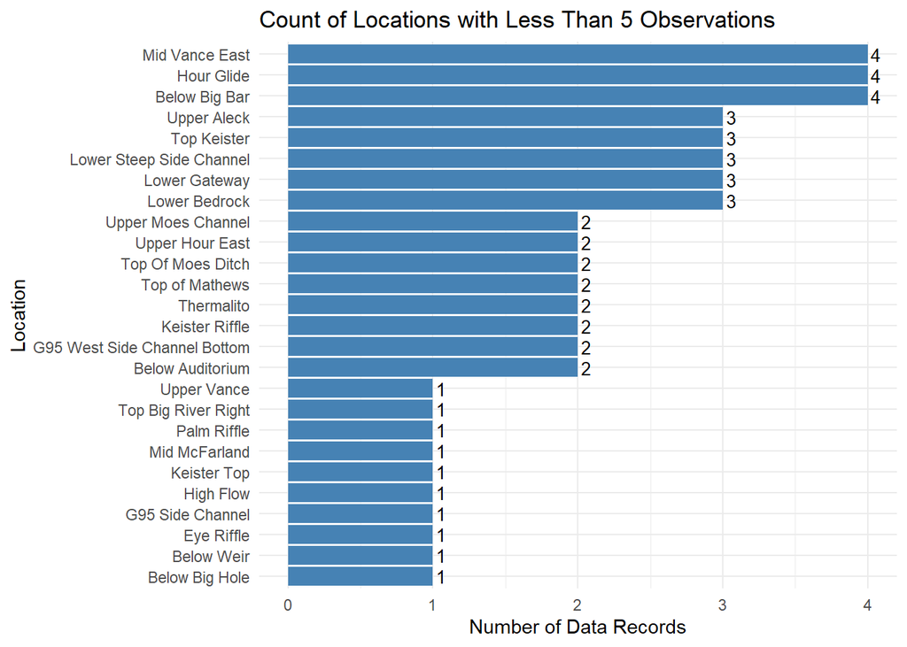

```r
#plotting those locations that appear less than 5 times
feather_redd_raw |>
  group_by(location) |>
  filter(n() < 5) |>
  ungroup() |>
  count(location) |>
  ggplot(aes(x = reorder(location, n), y = n)) +
  geom_bar(stat = "identity", fill = "steelblue") +
  coord_flip() +
  geom_text(aes(label = n), hjust = -0.3, size = 3.5) +
  labs(title = "Count of Locations with Less Than 5 Observations",
       x = "Location",
       y = "Number of Data Records") +
  theme_minimal()
```

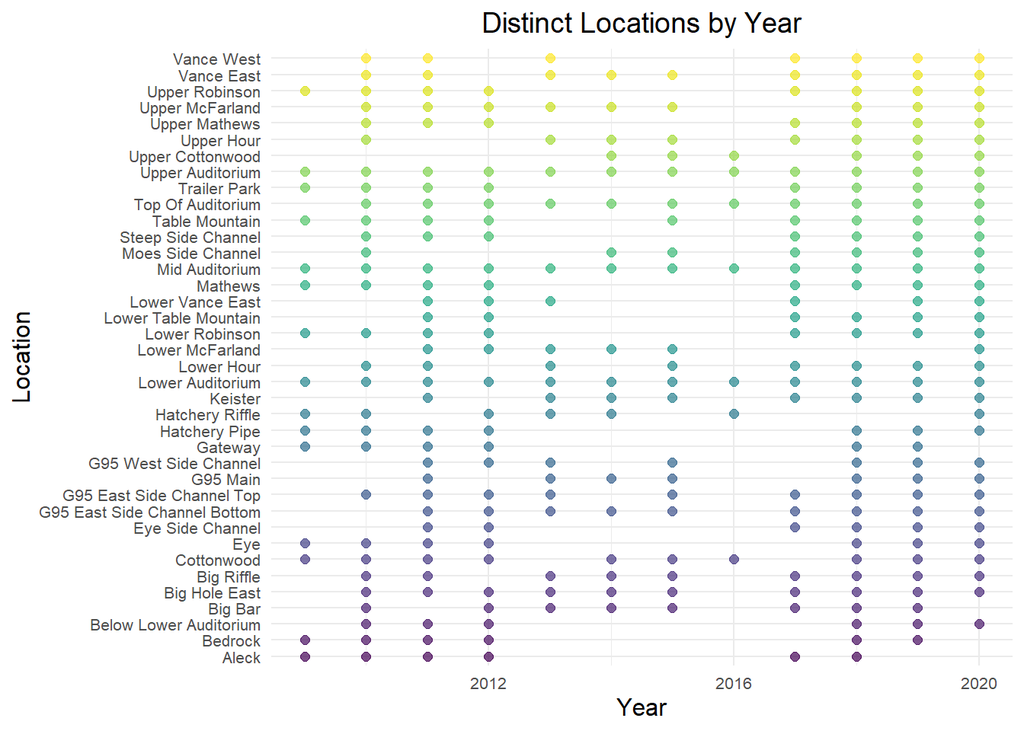

```r
location_frequent <- feather_redd_raw |>
  mutate(year = year(date)) |>
  select(location, year) |>
  group_by(location, year) |>
  distinct() |>
  ungroup() |>
  group_by(location) |>
  tally() |>
  filter(n > 5)

feather_redd_raw |>
  mutate(year = year(date)) |>
  select(location, year) |>
  group_by(location, year) |>
  distinct() |>
  filter(location %in% location_frequent$location) |>
  ggplot(aes(x = year, y = location, color = location)) +
  geom_point(size = 2, alpha = 0.7) +
  labs(title = "Distinct Locations by Year",
       x = "Year",
       y = "Location",
       color = "Location") +
  scale_color_viridis_d() +
  theme_minimal() +
  theme(plot.title = element_text(hjust = 0.5, size = 14),
        axis.title.x = element_text(size = 12),
        axis.title.y = element_text(size = 12),
        axis.text = element_text(size = 8),
        legend.position = "none")
```

Explore `type`

```r
#type
unique(feather_redd_raw$type)
```

```
## [1] "Area"               "Point"              "Questionable Redds"
## [4] NA
```

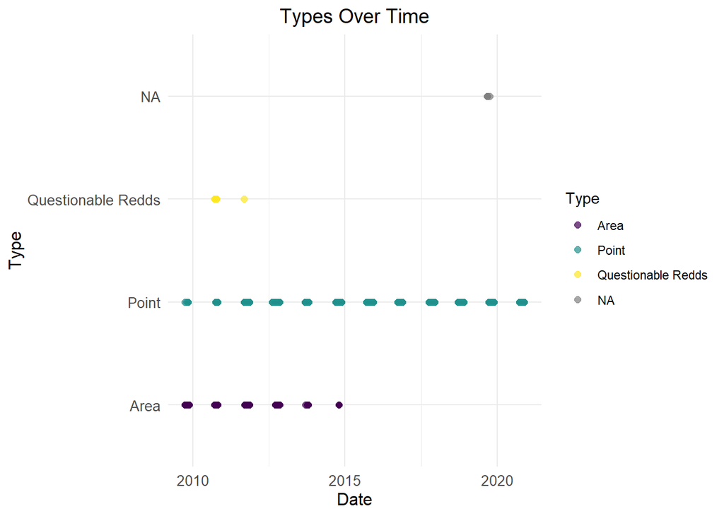

```r
ggplot(feather_redd_raw, aes(x = date, y = type, color = type)) +
  geom_point(size = 2, alpha = 0.7) +
  labs(title = "Types Over Time",
       x = "Date",
       y = "Type",
       color = "Type") +
   scale_color_viridis_d(na.value = "grey50") +
  theme_minimal() +
# Use Viridis color scale
  theme_minimal() +
  theme(plot.title = element_text(hjust = 0.5, size = 14),
        axis.title.x = element_text(size = 12),
        axis.title.y = element_text(size = 12),
        axis.text = element_text(size = 10))
```

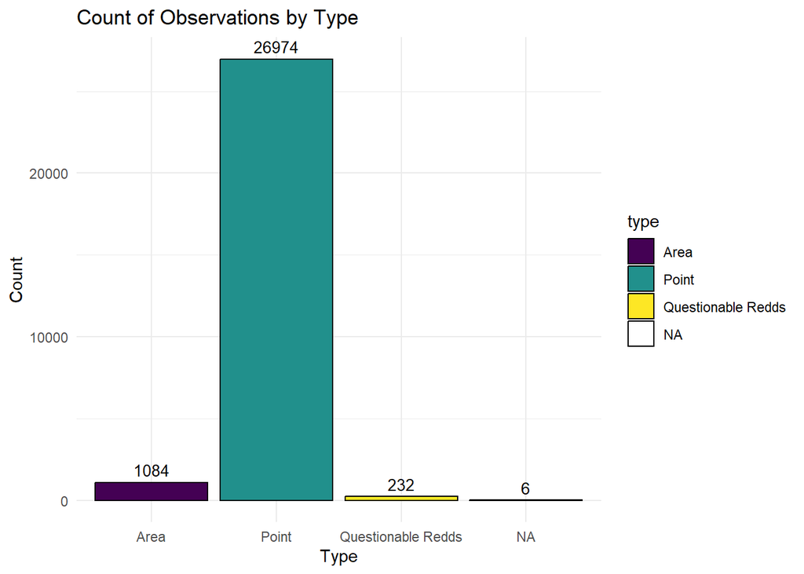

```r
feather_redd_raw |>
  group_by(type) |>
  summarise(n = n()) |>
  ggplot(aes(x = type, y = n, fill = type)) +
  geom_bar(stat = "identity", color = "black") +
  geom_text(aes(label = n), vjust = -0.5, size = 3.5) +
  scale_fill_viridis_d() +
  labs(title = "Count of Observations by Type",
       x = "Type",
       y = "Count") +
  theme_minimal()
```

Explore `redd_count`

```r
range(feather_redd_raw$redd_count)
```

```
## [1]   0 100
```

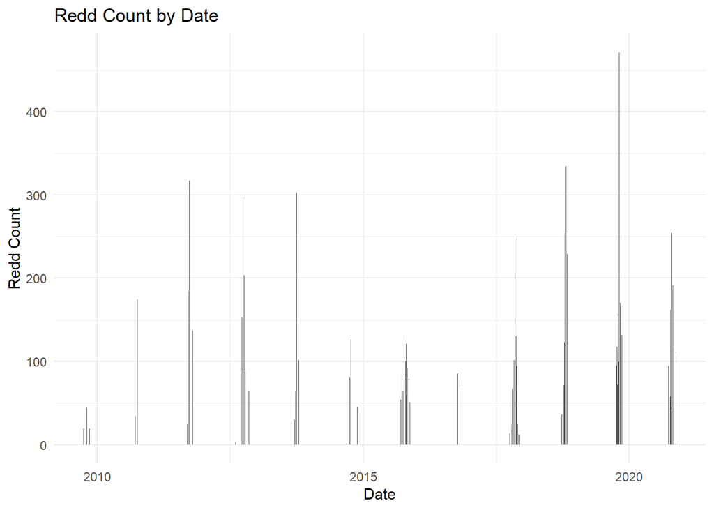

```r
ggplot(feather_redd_raw, aes(x = date, y = redd_count)) +
  geom_col() +
  labs(title = "Redd Count by Date",
       x = "Date",
       y = "Redd Count") +
  theme_minimal()
```

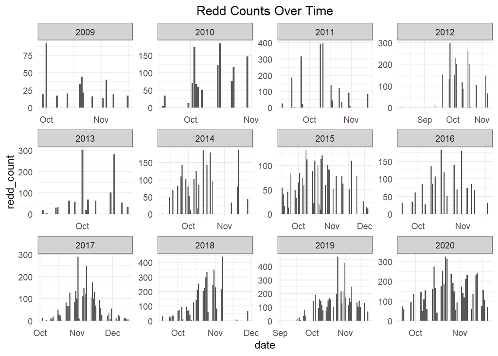

```r
feather_redd_raw |>
  filter(is.na(date)==FALSE) |>
  ggplot(aes(x = date, y = redd_count)) +
  geom_col() +
  facet_wrap(~year(date), scales = "free") +
  scale_x_date(labels = date_format("%b"), date_breaks = "1 month") +
  labs(title = "Redd Counts Over Time") +
  theme_minimal() +
  theme(
    strip.background = element_rect(fill = "lightgrey", color = "grey50"),
    plot.title = element_text(hjust = 0.5)
  )
```

Explore `salmon_count`

```r
range(feather_redd_raw$salmon_count, na.rm = TRUE)
```

```
## [1]   0 200
```

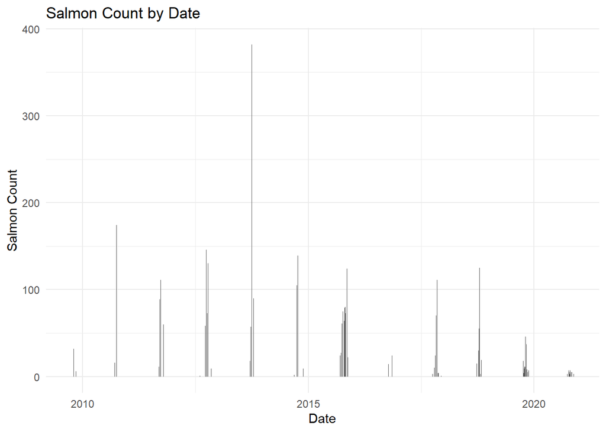

```r
ggplot(feather_redd_raw, aes(x = date, y = salmon_count)) +
  geom_col() +
  labs(title = "Salmon Count by Date",
       x = "Date",
       y = "Salmon Count") +
  theme_minimal()
```

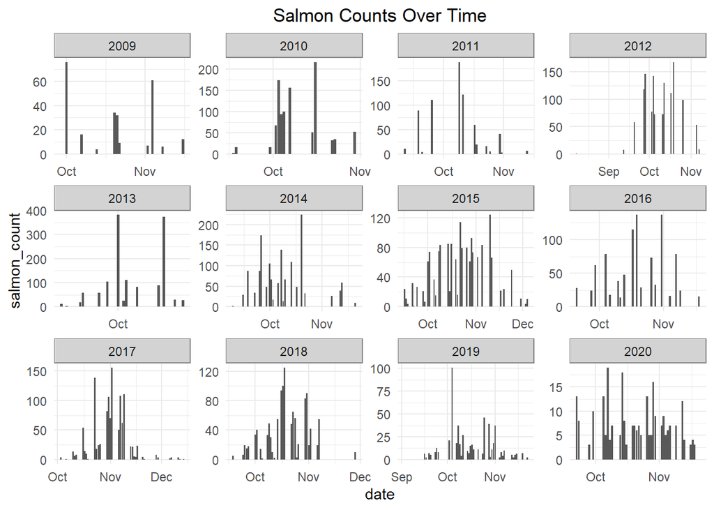

```r
feather_redd_raw |>
  filter(is.na(date)==FALSE) |>
  ggplot(aes(x = date, y = salmon_count)) +
  geom_col() +
  facet_wrap(~year(date), scales = "free") +
  scale_x_date(labels = date_format("%b"), date_breaks = "1 month") +
  labs(title = "Salmon Counts Over Time") +
  theme_minimal() +
  theme(
    strip.background = element_rect(fill = "lightgrey", color = "grey50"),
    plot.title = element_text(hjust = 0.5)
  )
```

Troubleshooting `latitude` and `longitude`

```r
lat_long_test <- feather_redd_raw |>
  filter(!is.na(longitude) | !is.na(latitude)) |>
  mutate(latitude = as.numeric(substring(latitude, 1, 2)) +
                      as.numeric(substring(latitude, 3, nchar(latitude))) / 1e5) |>
  mutate(longitude = - (as.numeric(substring(longitude, 1, 3)) +
                     as.numeric(substring(longitude, 4, nchar(longitude))) / 1e4)) |>
  filter(longitude > -125 | latitude < 40) |> #filtering those that seem off, for now
  glimpse()
```

```
## Rows: 895
## Columns: 17
## $ date                     <date> 2012-11-05, 2012-11-05, 2012-11-05, 2012-11-…
## $ location                 <chr> "Top Vance East", "Top Vance East", "Top Vanc…
## $ type                     <chr> "Area", "Point", "Point", "Point", "Point", "…
## $ redd_count               <dbl> 3, 1, 1, 1, 1, 1, 1, 1, 1, 1, 1, 1, 1, 1, 3, …
## $ salmon_count             <dbl> 0, 0, 0, 0, 1, 0, 1, 0, 2, 3, 1, 0, 0, 0, 0, …
## $ depth_m                  <dbl> NA, NA, NA, NA, NA, NA, NA, NA, NA, 0.56, NA,…
## $ pot_depth_m              <dbl> NA, NA, NA, NA, NA, NA, NA, NA, NA, 0.52, NA,…
## $ velocity                 <dbl> NA, NA, NA, NA, NA, NA, NA, NA, NA, 1.476378,…
## $ percent_fine_substrate   <dbl> NA, NA, NA, NA, NA, NA, NA, NA, NA, 0, NA, NA…
## $ percent_small_substrate  <dbl> NA, NA, NA, NA, NA, NA, NA, NA, NA, 50, NA, N…
## $ percent_medium_substrate <dbl> NA, NA, NA, NA, NA, NA, NA, NA, NA, 20, NA, N…
## $ percent_large_substrate  <dbl> NA, NA, NA, NA, NA, NA, NA, NA, NA, 30, NA, N…
## $ percent_boulder          <dbl> NA, NA, NA, NA, NA, NA, NA, NA, NA, 0, NA, NA…
## $ redd_width_m             <dbl> NA, NA, NA, NA, NA, NA, NA, NA, NA, 1, NA, NA…
## $ redd_length_m            <dbl> NA, NA, NA, NA, NA, NA, NA, NA, NA, 2, NA, NA…
## $ latitude                 <dbl> 39.02703, 39.02703, 39.02703, 39.02703, 39.02…
## $ longitude                <dbl> -121.3813, -121.3813, -121.5814, -121.3814, -…
```

# Data limitations

The lack of precision and availability of latitude and longitude coordinates limits the accuracy of spatial analyses. Without precise coordinates, we might be able to analyze data only at a broader geographic scale, for example by area names, rather than specific location points. This limitation affects our ability to pinpoint exact spawning sites and accurately map spawning habitat. It might be challenging to precisely define spawning habitat criteria in the absence of complete substrate data, which is critical for understanding the suitability of spawning environments. Furthermore, we will have limited ability to directly correlate redd density with specific environmental factors such as substrate type, depth, and velocity due to the missing data on these parameters. This gap makes it difficult to fully understand the habitat of Chinook salmon.

However, despite these limitations, we might be able to use the available data to calculate redd density as the number of redds per unit area. By delineating surveyed areas based on available location names or river reaches, we can estimate redd density and assess patterns over time. Additionally, we can analyze trends in abundance (harvest plus escapement) over multiple years (> 3 years), comparing current data with historical baselines from periods and recent years. These analyses can provide insights into changes in population dynamics and the effectiveness of habitat enhancement projects, even though the precision of habitat characterization may be limited.